# Biostat 203B Homework 3

## Q4. `patients` data

Patient information is available in `patients.csv.gz`. See https://mimic.mit.edu/docs/iv/modules/hosp/patients/ for details of each field in this file. The first 10 lines are

```bash
zcat < ~/mimic/hosp/patients.csv.gz | head
```

```
subject_id,gender,anchor_age,anchor_year,anchor_year_group,dod
10000032,F,52,2180,2014 - 2016,2180-09-09
10000048,F,23,2126,2008 - 2010,
10000058,F,33,2168,2020 - 2022,
10000068,F,19,2160,2008 - 2010,
10000084,M,72,2160,2017 - 2019,2161-02-13
10000102,F,27,2136,2008 - 2010,
10000108,M,25,2163,2014 - 2016,
10000115,M,24,2154,2017 - 2019,
10000117,F,48,2174,2008 - 2010,
```

### Q4.1 Ingestion

Import `patients.csv.gz` (https://mimic.mit.edu/docs/iv/modules/hosp/patients/) as a tibble `patients_tble`.

```r
patients_tble <- read_csv("~/mimic/hosp/patients.csv.gz")
```

### Q4.2 Summary and visualization

Summarize variables `gender` and `anchor_age` by graphics, and explain any patterns you see.

```r
gender_summary <- patients_tble %>%
  count(gender) %>%
  mutate(percentage = n / sum(n) * 100)

print(gender_summary)
```

```
# A tibble: 2 × 3
  gender      n percentage
  <chr>   <int>      <dbl>
1 F      191984       52.7
2 M      172643       47.3
```

```r
age_summary <- patients_tble %>%
  summarise(
    mean_age = mean(anchor_age, na.rm = TRUE),
    median_age = median(anchor_age, na.rm = TRUE),
    min_age = min(anchor_age, na.rm = TRUE),
    max_age = max(anchor_age, na.rm = TRUE)
  )

print(age_summary)
```

```
# A tibble: 1 × 4
  mean_age median_age min_age max_age
     <dbl>      <dbl>   <dbl>   <dbl>
1     48.9         48      18      91
```

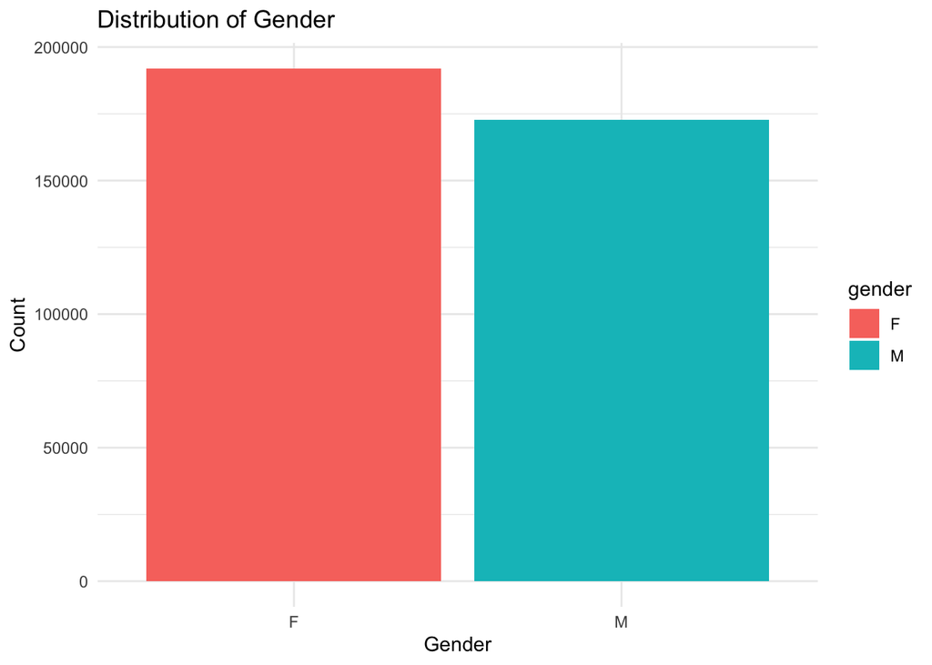

```r
gender_plot <- ggplot(patients_tble, aes(x = gender, fill = gender)) +
  geom_bar() +
  labs(
    title = "Distribution of Gender",
    x = "Gender",
    y = "Count"
  ) +
  theme_minimal()

print(gender_plot)
```

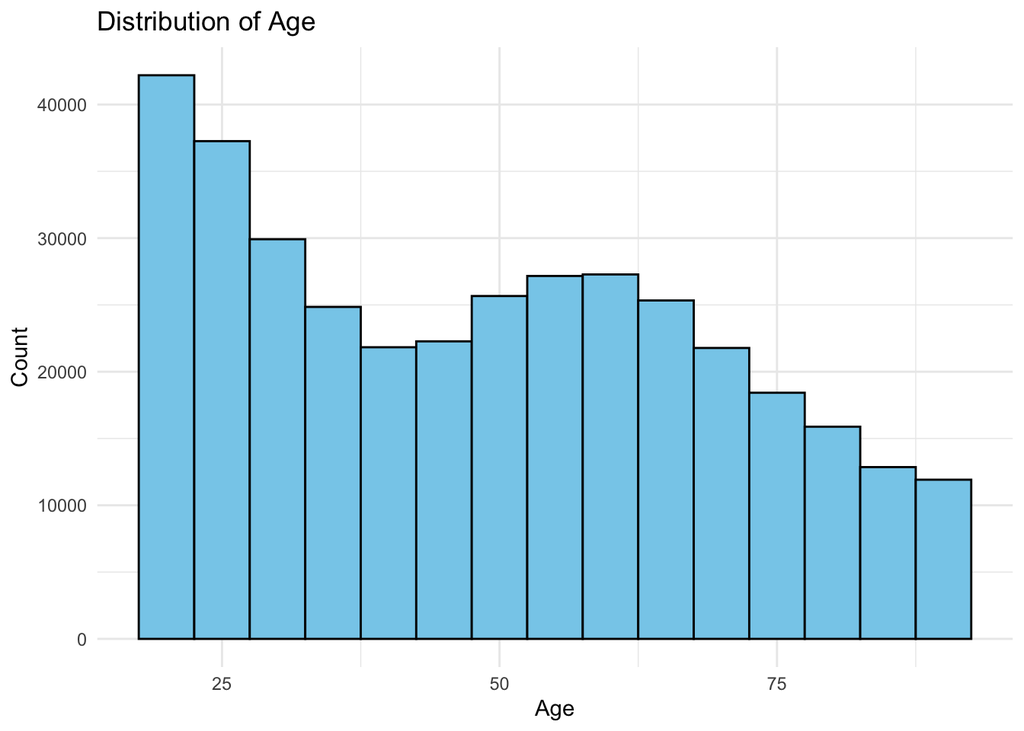

```r
age_plot <- ggplot(patients_tble, aes(x = anchor_age)) +
  geom_histogram(binwidth = 5, fill = "skyblue", color = "black") +
  labs(
    title = "Distribution of Age",
    x = "Age",
    y = "Count"
  ) +
  theme_minimal()

print(age_plot)
```

## Q5. Lab results

`labevents.csv.gz` (https://mimic.mit.edu/docs/iv/modules/hosp/labevents/) contains all laboratory measurements for patients. The first 10 lines are

```bash
zcat < ~/mimic/hosp/labevents.csv.gz | head
```

```
labevent_id,subject_id,hadm_id,specimen_id,itemid,order_provider_id,charttime,storetime,value,valuenum,valueuom,ref_range_lower,ref_range_upper,flag,priority,comments
1,10000032,,2704548,50931,P69FQC,2180-03-23 11:51:00,2180-03-23 15:56:00,___,95,mg/dL,70,100,,ROUTINE,"IF FASTING, 70-100 NORMAL, >125 PROVISIONAL DIABETES."
2,10000032,,36092842,51071,P69FQC,2180-03-23 11:51:00,2180-03-23 16:00:00,NEG,,,,,,ROUTINE,
3,10000032,,36092842,51074,P69FQC,2180-03-23 11:51:00,2180-03-23 16:00:00,NEG,,,,,,ROUTINE,
4,10000032,,36092842,51075,P69FQC,2180-03-23 11:51:00,2180-03-23 16:00:00,NEG,,,,,,ROUTINE,"BENZODIAZEPINE IMMUNOASSAY SCREEN DOES NOT DETECT SOME DRUGS,;INCLUDING LORAZEPAM, CLONAZEPAM, AND FLUNITRAZEPAM."
5,10000032,,36092842,51079,P69FQC,2180-03-23 11:51:00,2180-03-23 16:00:00,NEG,,,,,,ROUTINE,
6,10000032,,36092842,51087,P69FQC,2180-03-23 11:51:00,,,,,,,,ROUTINE,RANDOM.
7,10000032,,36092842,51089,P69FQC,2180-03-23 11:51:00,2180-03-23 16:15:00,,,,,,,ROUTINE,PRESUMPTIVELY POSITIVE.
8,10000032,,36092842,51090,P69FQC,2180-03-23 11:51:00,2180-03-23 16:00:00,NEG,,,,,,ROUTINE,METHADONE ASSAY DETECTS ONLY METHADONE (NOT OTHER OPIATES/OPIOIDS).
9,10000032,,36092842,51092,P69FQC,2180-03-23 11:51:00,2180-03-23 16:00:00,NEG,,,,,,ROUTINE,"OPIATE IMMUNOASSAY SCREEN DOES NOT DETECT SYNTHETIC OPIOIDS;SUCH AS METHADONE, OXYCODONE, FENTANYL, BUPRENORPHINE, TRAMADOL,;NALOXONE, MEPERIDINE.  SEE ONLINE LAB MANUAL FOR DETAILS."
```

`d_labitems.csv.gz` (https://mimic.mit.edu/docs/iv/modules/hosp/d_labitems/) is the dictionary of lab measurements.

```bash
zcat < ~/mimic/hosp/d_labitems.csv.gz | head
```

```
itemid,label,fluid,category
50801,Alveolar-arterial Gradient,Blood,Blood Gas
50802,Base Excess,Blood,Blood Gas
50803,"Calculated Bicarbonate, Whole Blood",Blood,Blood Gas
50804,Calculated Total CO2,Blood,Blood Gas
50805,Carboxyhemoglobin,Blood,Blood Gas
50806,"Chloride, Whole Blood",Blood,Blood Gas
50808,Free Calcium,Blood,Blood Gas
50809,Glucose,Blood,Blood Gas
50810,"Hematocrit, Calculated",Blood,Blood Gas
```

We are interested in the lab measurements of creatinine (50912), potassium (50971), sodium (50983), chloride (50902), bicarbonate (50882), hematocrit (51221), white blood cell count (51301), and glucose (50931). Retrieve a subset of `labevents.csv.gz` that only containing these items for the patients in `icustays_tble`. Further restrict to the last available measurement (by `storetime`) before the ICU stay. The final `labevents_tble` should have one row per ICU stay and columns for each lab measurement.

Hint: Use the Parquet format you generated in Homework 2. For reproducibility, make `labevents_pq` folder available at the current working directory `hw3`, for example, by a symbolic link.

```r
dlabitems_tble <- read_csv("~/mimic/hosp/d_labitems.csv.gz") %>%
  mutate(itemid = as.character(itemid)) %>%
  select(itemid, label) %>%
  collect()
```

```r
labevents_tble <- open_dataset("labevents_pq", format = "parquet") |>
  to_duckdb() |>
  select(subject_id, itemid, storetime, valuenum) |>
  filter(itemid %in% c("50912", "50971", "50983", "50902", "50882", "51221", "51301", "50931")) |>
  left_join(
    select(icustays_tble, subject_id, stay_id, intime),
    by = c("subject_id"),
    copy = TRUE
  ) |>
  filter(storetime < intime) |>
  group_by(subject_id, stay_id, itemid) |>
  slice_max(storetime, n = 1) |>
  select(-storetime, -intime) |>
  ungroup() |>
  left_join(dlabitems_tble, by = "itemid", copy = TRUE) |>
  select(-itemid) |>
  pivot_wider(names_from = label, values_from = valuenum) |>
  rename_with(~ str_to_lower(.)) |>
  rename(wbc = 'white blood cells') |>
  arrange(subject_id, stay_id) |>
  show_query() |>
  collect()
```

```
<SQL>
SELECT
  subject_id,
  stay_id,
  MAX(CASE WHEN ("label" = 'Chloride') THEN valuenum END) AS chloride,
  MAX(CASE WHEN ("label" = 'Glucose') THEN valuenum END) AS glucose,
  MAX(CASE WHEN ("label" = 'Bicarbonate') THEN valuenum END) AS bicarbonate,
  MAX(CASE WHEN ("label" = 'Hematocrit') THEN valuenum END) AS hematocrit,
  MAX(CASE WHEN ("label" = 'Potassium') THEN valuenum END) AS potassium,
  MAX(CASE WHEN ("label" = 'Creatinine') THEN valuenum END) AS creatinine,
  MAX(CASE WHEN ("label" = 'Sodium') THEN valuenum END) AS sodium,
  MAX(CASE WHEN ("label" = 'White Blood Cells') THEN valuenum END) AS wbc
FROM (
  SELECT subject_id, valuenum, stay_id, "label"
  FROM (
    SELECT subject_id, itemid, valuenum, stay_id
    FROM (
      SELECT
        q01.*,
        RANK() OVER (PARTITION BY subject_id, stay_id, itemid ORDER BY storetime DESC) AS col01
      FROM (
        SELECT LHS.*, stay_id, intime
        FROM (
          SELECT subject_id, itemid, storetime, valuenum
          FROM arrow_001
          WHERE (itemid IN ('50912', '50971', '50983', '50902', '50882', '51221', '51301', '50931'))
        ) LHS
        LEFT JOIN dbplyr_AcvQunruNm
          ON (LHS.subject_id = dbplyr_AcvQunruNm.subject_id)
      ) q01
      WHERE (storetime < intime)
    ) q01
    WHERE (col01 <= 1)
  ) LHS
  LEFT JOIN dbplyr_YkHTDfUPM6
    ON (LHS.itemid = dbplyr_YkHTDfUPM6.itemid)
) q01
GROUP BY subject_id, stay_id
ORDER BY subject_id, stay_id
```

```r
print(labevents_tble)
```

```
# A tibble: 88,086 × 10
   subject_id  stay_id chloride glucose bicarbonate hematocrit potassium
        <dbl>    <dbl>    <dbl>   <dbl>       <dbl>      <dbl>     <dbl>
 1   10000032 39553978       95     102          25       41.1       6.7
 2   10000690 37081114      100      85          26       36.1       4.8
 3   10000980 39765666      109      89          21       27.3       3.9
 4   10001217 34592300      104      87          30       37.4       4.1
 5   10001217 37067082      108     112          22       38.1       4.2
 6   10001725 31205490       98      NA          NA       NA         4.1
 7   10001843 39698942       97     131          28       31.4       3.9
 8   10001884 37510196       88     141          30       39.7       4.5
 9   10002013 39060235      102     288          24       34.9       3.5
10   10002114 34672098       NA      95          18       34.3       6.5
# ℹ 88,076 more rows
# ℹ 3 more variables: creatinine <dbl>, sodium <dbl>, wbc <dbl>
```

## Q6. Vitals from charted events

`chartevents.csv.gz` (https://mimic.mit.edu/docs/iv/modules/icu/chartevents/) contains all the charted data available for a patient. During their ICU stay, the primary repository of a patient’s information is their electronic chart. The `itemid` variable indicates a single measurement type in the database. The `value` variable is the value measured for `itemid`. The first 10 lines of `chartevents.csv.gz` are

```bash
zcat < ~/mimic/icu/chartevents.csv.gz | head
```

```
subject_id,hadm_id,stay_id,caregiver_id,charttime,storetime,itemid,value,valuenum,valueuom,warning
10000032,29079034,39553978,18704,2180-07-23 12:36:00,2180-07-23 14:45:00,226512,39.4,39.4,kg,0
10000032,29079034,39553978,18704,2180-07-23 12:36:00,2180-07-23 14:45:00,226707,60,60,Inch,0
10000032,29079034,39553978,18704,2180-07-23 12:36:00,2180-07-23 14:45:00,226730,152,152,cm,0
10000032,29079034,39553978,18704,2180-07-23 14:00:00,2180-07-23 14:18:00,220048,SR (Sinus Rhythm),,,0
10000032,29079034,39553978,18704,2180-07-23 14:00:00,2180-07-23 14:18:00,224642,Oral,,,0
10000032,29079034,39553978,18704,2180-07-23 14:00:00,2180-07-23 14:18:00,224650,None,,,0
10000032,29079034,39553978,18704,2180-07-23 14:00:00,2180-07-23 14:20:00,223761,98.7,98.7,°F,0
10000032,29079034,39553978,18704,2180-07-23 14:11:00,2180-07-23 14:17:00,220179,84,84,mmHg,0
10000032,29079034,39553978,18704,2180-07-23 14:11:00,2180-07-23 14:17:00,220180,48,48,mmHg,0
```

`d_items.csv.gz` (https://mimic.mit.edu/docs/iv/modules/icu/d_items/) is the dictionary for the `itemid` in `chartevents.csv.gz`.

```bash
zcat < ~/mimic/icu/d_items.csv.gz | head
```

```
itemid,label,abbreviation,linksto,category,unitname,param_type,lownormalvalue,highnormalvalue
220001,Problem List,Problem List,chartevents,General,,Text,,
220003,ICU Admission date,ICU Admission date,datetimeevents,ADT,,Date and time,,
220045,Heart Rate,HR,chartevents,Routine Vital Signs,bpm,Numeric,,
220046,Heart rate Alarm - High,HR Alarm - High,chartevents,Alarms,bpm,Numeric,,
220047,Heart Rate Alarm - Low,HR Alarm - Low,chartevents,Alarms,bpm,Numeric,,
220048,Heart Rhythm,Heart Rhythm,chartevents,Routine Vital Signs,,Text,,
220050,Arterial Blood Pressure systolic,ABPs,chartevents,Routine Vital Signs,mmHg,Numeric,90,140
220051,Arterial Blood Pressure diastolic,ABPd,chartevents,Routine Vital Signs,mmHg,Numeric,60,90
220052,Arterial Blood Pressure mean,ABPm,chartevents,Routine Vital Signs,mmHg,Numeric,,
```

We are interested in the vitals for ICU patients: heart rate (220045), systolic non-invasive blood pressure (220179), diastolic non-invasive blood pressure (220180), body temperature in Fahrenheit (223761), and respiratory rate (220210). Retrieve a subset of `chartevents.csv.gz` only containing these items for the patients in `icustays_tble`. Further restrict to the first vital measurement within the ICU stay. The final `chartevents_tble` should have one row per ICU stay and columns for each vital measurement.

Hint: Use the Parquet format you generated in Homework 2. For reproducibility, make `chartevents_pq` folder available at the current working directory, for example, by a symbolic link.

```r
d_items_tble <- read_csv("~/mimic/icu/d_items.csv.gz") %>%
  mutate(itemid = as.character(itemid)) %>%
  select(itemid, label) %>%
  collect()
```

```r
chartevents_tble <- open_dataset("chartevents_pq", format = "parquet") |>
  to_duckdb() |>
  select(subject_id, stay_id, charttime, itemid, valuenum) |>
  filter(itemid %in% c("220045", "220179", "220180", "223761", "220210")) |>
  left_join(
    select(icustays_tble, subject_id, stay_id, intime, outtime),
    by = c("subject_id", "stay_id"),
    copy = TRUE
  ) |>
  filter(charttime >= intime & charttime <= outtime) |>
  group_by(subject_id, stay_id, itemid) |>
  slice_min(charttime, n = 1) |>
  select(-charttime, -intime, -outtime) |>
  ungroup() |>
  left_join(d_items_tble, by = "itemid", copy = TRUE) |>
  select(-itemid) |>
  pivot_wider(names_from = label, values_from = valuenum) |>
  rename_with(~ str_to_lower(.)) |>
  rename(
    heart_rate = 'heart rate',
    systolic_bp = 'non invasive blood pressure systolic',
    diastolic_bp = 'non invasive blood pressure diastolic',
    temperature_f = 'temperature fahrenheit',
    respiratory_rate = 'respiratory rate'
  ) |>
  arrange(subject_id, stay_id) |>
  show_query() |>
  collect()
```

```
<SQL>
SELECT
  subject_id,
  stay_id,
  MAX(CASE WHEN ("label" = 'Respiratory Rate') THEN valuenum END) AS respiratory_rate,
  MAX(CASE WHEN ("label" = 'Heart Rate') THEN valuenum END) AS heart_rate,
  MAX(CASE WHEN ("label" = 'Temperature Fahrenheit') THEN valuenum END) AS temperature_f,
  MAX(CASE WHEN ("label" = 'Non Invasive Blood Pressure systolic') THEN valuenum END) AS systolic_bp,
  MAX(CASE WHEN ("label" = 'Non Invasive Blood Pressure diastolic') THEN valuenum END) AS diastolic_bp
FROM (
  SELECT subject_id, stay_id, valuenum, "label"
  FROM (
    SELECT subject_id, stay_id, itemid, valuenum
    FROM (
      SELECT
        q01.*,
        RANK() OVER (PARTITION BY subject_id, stay_id, itemid ORDER BY charttime) AS col01
      FROM (
        SELECT LHS.*, intime, outtime
        FROM (
          SELECT subject_id, stay_id, charttime, itemid, valuenum
          FROM arrow_002
          WHERE (itemid IN ('220045', '220179', '220180', '223761', '220210'))
        ) LHS
        LEFT JOIN dbplyr_uzZds9P5sn
          ON (
            LHS.subject_id = dbplyr_uzZds9P5sn.subject_id AND
            LHS.stay_id = dbplyr_uzZds9P5sn.stay_id
          )
      ) q01
      WHERE (charttime >= intime AND charttime <= outtime)
    ) q01
    WHERE (col01 <= 1)
  ) LHS
  LEFT JOIN dbplyr_YkEOWXRvJ1
    ON (LHS.itemid = dbplyr_YkEOWXRvJ1.itemid)
) q01
GROUP BY subject_id, stay_id
ORDER BY subject_id, stay_id
```

```r
print(chartevents_tble)
```

```
# A tibble: 94,424 × 7
   subject_id  stay_id respiratory_rate heart_rate temperature_f systolic_bp
        <dbl>    <dbl>            <dbl>      <dbl>         <dbl>       <dbl>
 1   10000032 39553978               24         91          98.7          84
 2   10000690 37081114               23         79          97.7         107
 3   10000980 39765666               23         77          98           150
 4   10001217 34592300               11         96          97.6         167
 5   10001217 37067082               18         86          98.5         151
 6   10001725 31205490               19         55          97.7          73
 7   10001843 39698942               17        118          97.9         112
 8   10001884 37510196               10         38          98.1         180
 9   10002013 39060235               14         80          97.2         104
10   10002114 34672098               22        105          97.9         104
# ℹ 94,414 more rows
# ℹ 1 more variable: diastolic_bp <dbl>
```

## Q7. Putting things together

Let us create a tibble `mimic_icu_cohort` for all ICU stays, where rows are all ICU stays of adults (age at `intime` >= 18) and columns contain at least following variables

- all variables in `icustays_tble`
- all variables in `admissions_tble`
- all variables in `patients_tble`
- the last lab measurements before the ICU stay in `labevents_tble`
- the first vital measurements during the ICU stay in `chartevents_tble`

The final `mimic_icu_cohort` should have one row per ICU stay and columns for each variable.

```r
icustays_tble <- collect(icustays_tble)
admissions_tble <- collect(admissions_tble)
patients_tble <- collect(patients_tble)
labevents_tble <- collect(labevents_tble)
chartevents_tble <- collect(chartevents_tble)

mimic_icu_cohort <- icustays_tble |>
  left_join(admissions_tble, by = c("subject_id", "hadm_id")) |>
  left_join(patients_tble, by = "subject_id") |>
  filter(anchor_age + (year(intime) - anchor_year) >= 18) |>
  left_join(labevents_tble, by = c("subject_id", "stay_id")) |>
  left_join(chartevents_tble, by = c("subject_id", "stay_id")) |>
  arrange(subject_id, hadm_id)
print(mimic_icu_cohort)
```

```
# A tibble: 94,458 × 41
   subject_id  hadm_id  stay_id first_careunit last_careunit intime
        <dbl>    <dbl>    <dbl> <chr>          <chr>         <dttm>
 1   10000032 29079034 39553978 Medical Inten… Medical Inte… 2180-07-23 14:00:00
 2   10000690 25860671 37081114 Medical Inten… Medical Inte… 2150-11-02 19:37:00
 3   10000980 26913865 39765666 Medical Inten… Medical Inte… 2189-06-27 08:42:00
 4   10001217 24597018 37067082 Surgical Inte… Surgical Int… 2157-11-20 19:18:02
 5   10001217 27703517 34592300 Surgical Inte… Surgical Int… 2157-12-19 15:42:24
 6   10001725 25563031 31205490 Medical/Surgi… Medical/Surg… 2110-04-11 15:52:22
 7   10001843 26133978 39698942 Medical/Surgi… Medical/Surg… 2134-12-05 18:50:03
 8   10001884 26184834 37510196 Medical Inten… Medical Inte… 2131-01-11 04:20:05
 9   10002013 23581541 39060235 Cardiac Vascu… Cardiac Vasc… 2160-05-18 10:00:53
10   10002114 27793700 34672098 Coronary Care… Coronary Car… 2162-02-17 23:30:00
# ℹ 94,448 more rows
# ℹ 35 more variables: outtime <dttm>, los.x <dbl>, admittime <dttm>,
#   dischtime <dttm>, deathtime <dttm>, admission_type <chr>,
#   admit_provider_id <chr>, admission_location <chr>,
#   discharge_location <chr>, insurance <chr>, language <chr>,
#   marital_status <chr>, race <chr>, edregtime <dttm>, edouttime <dttm>,
#   hospital_expire_flag <dbl>, los.y <drtn>, gender <chr>, anchor_age <dbl>, …
```

## Q8. Exploratory data analysis (EDA)

Summarize the following information about the ICU stay cohort `mimic_icu_cohort` using appropriate numerics or graphs:

- Length of ICU stay `los` vs demographic variables (race, insurance, marital_status, gender, age at intime)
- Length of ICU stay `los` vs the last available lab measurements before ICU stay
- Length of ICU stay `los` vs the first vital measurements within the ICU stay
- Length of ICU stay `los` vs first ICU unit

```r
mimic_icu_cohort_df <- mimic_icu_cohort |> collect()

print(mimic_icu_cohort_df)
```

```
# A tibble: 94,458 × 41
   subject_id  hadm_id  stay_id first_careunit last_careunit intime
        <dbl>    <dbl>    <dbl> <chr>          <chr>         <dttm>
 1   10000032 29079034 39553978 Medical Inten… Medical Inte… 2180-07-23 14:00:00
 2   10000690 25860671 37081114 Medical Inten… Medical Inte… 2150-11-02 19:37:00
 3   10000980 26913865 39765666 Medical Inten… Medical Inte… 2189-06-27 08:42:00
 4   10001217 24597018 37067082 Surgical Inte… Surgical Int… 2157-11-20 19:18:02
 5   10001217 27703517 34592300 Surgical Inte… Surgical Int… 2157-12-19 15:42:24
 6   10001725 25563031 31205490 Medical/Surgi… Medical/Surg… 2110-04-11 15:52:22
 7   10001843 26133978 39698942 Medical/Surgi… Medical/Surg… 2134-12-05 18:50:03
 8   10001884 26184834 37510196 Medical Inten… Medical Inte… 2131-01-11 04:20:05
 9   10002013 23581541 39060235 Cardiac Vascu… Cardiac Vasc… 2160-05-18 10:00:53
10   10002114 27793700 34672098 Coronary Care… Coronary Car… 2162-02-17 23:30:00
# ℹ 94,448 more rows
# ℹ 35 more variables: outtime <dttm>, los.x <dbl>, admittime <dttm>,
#   dischtime <dttm>, deathtime <dttm>, admission_type <chr>,
#   admit_provider_id <chr>, admission_location <chr>,
#   discharge_location <chr>, insurance <chr>, language <chr>,
#   marital_status <chr>, race <chr>, edregtime <dttm>, edouttime <dttm>,
#   hospital_expire_flag <dbl>, los.y <drtn>, gender <chr>, anchor_age <dbl>, …
```

```r
summary(mimic_icu_cohort_df)
```

```
   subject_id          hadm_id            stay_id         first_careunit
 Min.   :10000032   Min.   :20000094   Min.   :30000153   Length:94458
 1st Qu.:12514630   1st Qu.:22482122   1st Qu.:32506785   Class :character
 Median :15005544   Median :24982475   Median :34999442   Mode  :character
 Mean   :15004217   Mean   :24981846   Mean   :34998318
 3rd Qu.:17517575   3rd Qu.:27465060   3rd Qu.:37490986
 Max.   :19999987   Max.   :29999828   Max.   :39999858

 last_careunit          intime
 Length:94458       Min.   :2110-01-11 10:16:06.0
 Class :character   1st Qu.:2133-11-20 18:31:35.5
 Mode  :character   Median :2153-09-27 20:32:30.0
                    Mean   :2153-10-25 12:54:18.1
                    3rd Qu.:2173-11-22 06:48:00.0
                    Max.   :2214-07-22 17:05:53.0

    outtime                           los.x
 Min.   :2110-01-12 17:17:47.00   Min.   :  0.00125
 1st Qu.:2133-11-23 07:15:37.75   1st Qu.:  1.09621
 Median :2153-10-01 12:22:23.00   Median :  1.96565
 Mean   :2153-10-28 15:34:24.78   Mean   :  3.63002
 3rd Qu.:2173-11-26 18:02:40.25   3rd Qu.:  3.86258
 Max.   :2214-07-26 17:13:57.00   Max.   :226.40308
 NA's   :14                       NA's   :14
   admittime                        dischtime
 Min.   :2110-01-11 10:14:00.00   Min.   :2110-01-15 17:31:00.0
 1st Qu.:2133-11-18 08:52:15.00   1st Qu.:2133-11-27 17:55:00.0
 Median :2153-09-25 21:37:00.00   Median :2153-10-06 06:12:30.0
 Mean   :2153-10-23 06:08:41.18   Mean   :2153-11-04 01:29:54.3
 3rd Qu.:2173-11-21 19:10:15.00   3rd Qu.:2173-11-30 06:30:15.0
 Max.   :2214-07-18 14:05:00.00   Max.   :2214-08-11 16:08:00.0

   deathtime                      admission_type     admit_provider_id
 Min.   :2110-01-25 09:40:00.00   Length:94458       Length:94458
 1st Qu.:2133-09-27 14:15:00.00   Class :character   Class :character
 Median :2153-12-10 14:21:00.00   Mode  :character   Mode  :character
 Mean   :2153-11-13 05:18:05.85
 3rd Qu.:2174-01-21 07:10:00.00
 Max.   :2211-01-17 12:34:00.00
 NA's   :83117
```

[output cut: 49 more lines]

```
 Min.   :  0.10   Min.   :  0.0    Min.   :   0.00   Min.   :  0.00
 1st Qu.:  6.80   1st Qu.: 15.0    1st Qu.:  74.00   1st Qu.: 97.70
 Median :  9.30   Median : 18.0    Median :  86.00   Median : 98.20
 Mean   : 11.08   Mean   : 19.2    Mean   :  88.69   Mean   : 98.11
 3rd Qu.: 13.20   3rd Qu.: 22.0    3rd Qu.: 101.00   3rd Qu.: 98.70
 Max.   :513.40   Max.   :180.0    Max.   :8400.00   Max.   :998.90
 NA's   :6858     NA's   :160      NA's   :35        NA's   :1774
  systolic_bp     diastolic_bp
 Min.   :    0   Min.   :    0.00
 1st Qu.:  105   1st Qu.:   57.00
 Median :  121   Median :   68.00
 Mean   :  123   Mean   :   73.06
 3rd Qu.:  138   3rd Qu.:   80.00
 Max.   :12262   Max.   :82127.00
 NA's   :1367    NA's   :1373
```

```r
mimic_icu_cohort_df <- mimic_icu_cohort_df |> drop_na()
```

```r
# 1. Relationship Between ICU Length of Stay (LOS) and Demographic Variables
# 1.1 LOS vs Race
ggplot(mimic_icu_cohort_df, aes(x = race, y = los, fill = race)) +
  geom_boxplot(na.rm = TRUE) +
  labs(title = "Length of ICU Stay vs Race", x = "Race",
       y = "Length of Stay (days)") +
  theme_minimal()

# 1.2 LOS vs Insurance
ggplot(mimic_icu_cohort_df, aes(x = insurance, y = los, fill = insurance)) +
  geom_boxplot() +
  labs(title = "Length of ICU Stay vs Insurance",
       x = "Insurance", y = "Length of Stay (days)") +
  theme_minimal()

# 1.3 LOS vs Marital Status
ggplot(mimic_icu_cohort_df, aes(x = marital_status, y = los,
                                fill = marital_status)) +
  geom_boxplot() +
  labs(title = "Length of ICU Stay vs Marital Status",
       x = "Marital Status", y = "Length of Stay (days)") +
  theme_minimal()

# 1.4 LOS vs Gender
ggplot(mimic_icu_cohort_df, aes(x = gender, y = los, fill = gender)) +
  geom_boxplot() +
  labs(title = "Length of ICU Stay vs Gender",
       x = "Gender", y = "Length of Stay (days)") +
  theme_minimal()

# 1.5 LOS vs Age at ICU Admission
ggplot(mimic_icu_cohort_df, aes(x = anchor_age +
                                  (year(intime) - anchor_year), y = los)) +
  geom_point(alpha = 0.5) +
  labs(title = "Length of ICU Stay vs Age at Admission",
       x = "Age at Admission",
       y = "Length of Stay (days)") +
  theme_minimal()

# 2. Relationship Between ICU Length of Stay (LOS) and Last Pre-ICU
# 2.1 LOS vs Creatinine
ggplot(mimic_icu_cohort_df, aes(x = creatinine, y = los)) +
  geom_point(alpha = 0.5) +
  labs(title = "Length of ICU Stay vs Creatinine",
       x = "Creatinine", y = "Length of Stay (days)") +
  theme_minimal()

# 2.2 LOS vs Sodium
ggplot(mimic_icu_cohort_df, aes(x = sodium, y = los)) +
  geom_point(alpha = 0.5) +
  labs(title = "Length of ICU Stay vs Sodium", x = "Sodium",
       y = "Length of Stay (days)") +
  theme_minimal()

# 3. Relationship Between ICU Length of Stay (LOS) and First Vital Signs
# 3.1 LOS vs Heart Rate
ggplot(mimic_icu_cohort_df, aes(x = heart_rate, y = los)) +
  geom_point(alpha = 0.5) +
  labs(title = "Length of ICU Stay vs Heart Rate",
       x = "Heart Rate", y = "Length of Stay (days)") +
  theme_minimal()

# 3.2 LOS vs Systolic Blood Pressure
ggplot(mimic_icu_cohort_df, aes(x = systolic_bp, y = los)) +
  geom_point(alpha = 0.5) +
  labs(title = "Length of ICU Stay vs Systolic BP",
       x = "Systolic BP", y = "Length of Stay (days)") +
  theme_minimal()

# 4. Relationship Between ICU Length of Stay (LOS) and First ICU Unit
ggplot(mimic_icu_cohort_df, aes(x = first_careunit, y = los)) +
  geom_boxplot() +
  labs(title = "Length of ICU Stay vs First ICU Unit",
       x = "First ICU Unit", y = "Length of Stay (days)") +
  theme_minimal()
```

[output not shown]